# **An Analysis of the Evolution of Movies and their Ratings**

## Timothy Wen

Throughout the history of cinema, as film making software and technology developed, the quality of movies have improved by leaps and bounds. From animations to documentaries, we have seen improvements in a film's sound quality, video quality, production, and even movie length. This is especially true when we take a look at movies created by major studios. For example, if we look back at Pixar's first animation, *Toy Story*, released in 1995, we can see that it only had a length of 81 minutes. Comparatively, all their movies in recents years have consistently been 100 minutes each. Although that may not seem like much, those extra 19 minutes constitute a 23.5% increase in movie duration. That extra 19 minutes means an extra 19 minutes of additional animation, voice acting, editing, and more.

Now this begs the question, did this increase of 23.5% improve ratings, and if it did, by how much? As an avid movie watcher who has benefited from many hours of improved video quality, my goal of this tutorial is to represent the relationships various factors have on a movie's ratings. For this assignment, I will only be analyzing movies and not short films or TV series.

# **Data Collection/Curation**

To begin, we first need to find a comprehensive dataset that contains information on the year a movie came out, its runtime, and its rating. Thankfully, IMDb, the online database of information on all kinds of video productions, provides several datasets with various information using a movie's unique alphanumeric identifier. To access these datasets, you could visit https://www.imdb.com/interfaces/.

Because datasets are saved differently, we will need to convert IMDb's dataset that is stored as a tsv, a tab separated values, into a csv, a comma separated value. This way, we can use the pandas command, 'read_csv' to turn this table into a dataframe. A dataframe is a datastructure that stores rows of values that have characteristics that are stored within the columns. (More information about the functions of a dataframe and how it can be used can be found at https://pandas.pydata.org/docs/reference/api/pandas.DataFrame.html)

Next, because different IMDb datasets store different information, we will have to merge two of the databases into one. When doing this, it is important to not merge the two datasets incorrectly. In this case, IMDb gives a unique classifier to each title under the column 'tconst.' We can use this consistency to combine the tables into one.

```python
import pandas as pd
import numpy as np
import warnings
warnings.filterwarnings('ignore')

# contains information on the release year, movie's title, and runtime in minutes
titleTSV = 'https://datasets.imdbws.com/title.basics.tsv.gz'
titleBasic = pd.read_csv(titleTSV, sep = '\t')

# contains information on the average rating of the movie and the number of votes for the movie
ratingsTSV = 'https://datasets.imdbws.com/title.ratings.tsv.gz'
ratingsBasic = pd.read_csv(ratingsTSV, sep = '\t')

info = titleBasic.merge(ratingsBasic, on='tconst')
info.head()
```

|  | tconst | titleType | primaryTitle | originalTitle | isAdult | startYear | endYear | runtimeMinutes | genres | averageRating | numVotes |
| --- | --- | --- | --- | --- | --- | --- | --- | --- | --- | --- | --- |
| 0 | tt0000001 | short | Carmencita | Carmencita | 0 | 1894 | \N | 1 | Documentary,Short | 5.7 | 1879 |
| 1 | tt0000002 | short | Le clown et ses chiens | Le clown et ses chiens | 0 | 1892 | \N | 5 | Animation,Short | 5.9 | 249 |
| 2 | tt0000003 | short | Pauvre Pierrot | Pauvre Pierrot | 0 | 1892 | \N | 4 | Animation,Comedy,Romance | 6.5 | 1654 |
| 3 | tt0000004 | short | Un bon bock | Un bon bock | 0 | 1892 | \N | 12 | Animation,Short | 5.8 | 162 |
| 4 | tt0000005 | short | Blacksmith Scene | Blacksmith Scene | 0 | 1893 | \N | 1 | Comedy,Short | 6.2 | 2479 |

As you can see, there are various columns but there are some important ones to note before our analysis:

- tconst: the unique classifier for each movie
- titleType: the film classification of every movie
- primaryTitle: The English translation of a movie's title
- startYear: The year each movie was released
- runtimeMinutes: How long each movie is
- averageRating: The score a movie received from all the people who voted on a scale of 1 to 10
- numVotes: The number of people who voted for this movie whose scores are averaged as the movie's rating metric
- genres: The genre of the movie(from 1 to 3 types per movie)

# **Modifying DataFrame**

```python
# Just to show the various types of films that are stored
print(info['titleType'].unique())

info = info[info['titleType'] == 'movie']

# Prints whether the number of rows that have no runtime
print('Rows without runtimes: ' + str(len(info[info['runtimeMinutes'] == r'\N'])))
print('Rows without ratings: ' + str(len(info[info['averageRating'] == r'\N'])))
info
```

```
['short' 'movie' 'tvEpisode' 'tvSeries' 'tvShort' 'tvMovie' 'tvMiniSeries'
 'tvSpecial' 'video' 'videoGame']
Rows without runtimes: 27965
Rows without ratings: 0
```

|  | tconst | titleType | primaryTitle | originalTitle | isAdult | startYear | endYear | runtimeMinutes | genres | averageRating | numVotes |
| --- | --- | --- | --- | --- | --- | --- | --- | --- | --- | --- | --- |
| 339 | tt0000502 | movie | Bohemios | Bohemios | 0 | 1905 | \N | 100 | \N | 4.5 | 14 |
| 373 | tt0000574 | movie | The Story of the Kelly Gang | The Story of the Kelly Gang | 0 | 1906 | \N | 70 | Action,Adventure,Biography | 6.0 | 765 |
| 382 | tt0000591 | movie | The Prodigal Son | L'enfant prodigue | 0 | 1907 | \N | 90 | Drama | 4.5 | 18 |
| 397 | tt0000615 | movie | Robbery Under Arms | Robbery Under Arms | 0 | 1907 | \N | \N | Drama | 4.5 | 23 |
| 405 | tt0000630 | movie | Hamlet | Amleto | 0 | 1908 | \N | \N | Drama | 3.8 | 24 |
| ... | ... | ... | ... | ... | ... | ... | ... | ... | ... | ... | ... |
| 1244427 | tt9916270 | movie | Il talento del calabrone | Il talento del calabrone | 0 | 2020 | \N | 84 | Thriller | 5.8 | 1333 |
| 1244431 | tt9916362 | movie | Coven | Akelarre | 0 | 2020 | \N | 92 | Drama,History | 6.4 | 4641 |
| 1244435 | tt9916428 | movie | The Secret of China | Hong xing zhao yao Zhong guo | 0 | 2019 | \N | \N | Adventure,History,War | 3.6 | 15 |
| 1244439 | tt9916538 | movie | Kuambil Lagi Hatiku | Kuambil Lagi Hatiku | 0 | 2019 | \N | 123 | Drama | 8.3 | 6 |
| 1244450 | tt9916730 | movie | 6 Gunn | 6 Gunn | 0 | 2017 | \N | 116 | \N | 8.7 | 6 |

278296 rows × 11 columns

Next, as you can see in the dataframe, there are rows that do not contain a runtime but no rows that do not contain a rating. As such, we need to filter out the rows that contain the empty symbol, '\N' so that we only have data that we can match. It is important to filter out information that is missing because it may cause problems down the line when plotting points or doing calculations. While we are at it, we can remove some of the unnecessary columns. For instance, movies are not series so they do not have an end year so that column would be unnecessary to our analysis.

Additionally, we will also be getting rid of some rows where the number of votes on a movie is negligible. This is because these films may have been small, private productions that did not receive much publicity or watch time compared to other films that are more relevant to what we are looking for. In this case, a good cut off might be 1000. Considering how many people watch movies around the world, if not even 1000 people were to vote, then the movie was most likely never that relevant.

```python
info = info[info['runtimeMinutes'] != r'\N']
info = info[info['startYear'] != r'\N']

info.rename(columns = {'startYear':'releaseYear'}, inplace = True)

#drops unnecessary columns
info = info.drop('endYear', axis = 1)
info = info.drop('titleType', axis = 1)
info = info.drop('originalTitle', axis = 1)
info = info.drop('isAdult', axis = 1)

#drop rows with number of votes that are less than 1000
info = info[info['numVotes'] >= 1000]

info
```

|  | tconst | primaryTitle | releaseYear | runtimeMinutes | genres | averageRating | numVotes |
| --- | --- | --- | --- | --- | --- | --- | --- |
| 1008 | tt0002130 | Dante's Inferno | 1911 | 71 | Adventure,Drama,Fantasy | 7.0 | 2841 |
| 1205 | tt0002844 | Fantômas: In the Shadow of the Guillotine | 1913 | 54 | Crime,Drama | 6.9 | 2240 |
| 1236 | tt0003014 | Ingeborg Holm | 1913 | 96 | Drama | 7.0 | 1207 |
| 1241 | tt0003037 | Fantomas: The Man in Black | 1913 | 61 | Crime,Drama | 6.9 | 1551 |
| 1262 | tt0003165 | Fantômas: The Dead Man Who Killed | 1913 | 90 | Crime,Drama,Mystery | 6.9 | 1218 |
| ... | ... | ... | ... | ... | ... | ... | ... |
| 1244083 | tt9907782 | The Cursed | 2021 | 111 | Fantasy,Horror,Mystery | 6.3 | 6571 |
| 1244086 | tt9908390 | Le lion | 2020 | 95 | Comedy | 5.4 | 1095 |
| 1244197 | tt9911196 | The Marriage Escape | 2020 | 103 | Comedy,Drama | 7.5 | 3593 |
| 1244427 | tt9916270 | Il talento del calabrone | 2020 | 84 | Thriller | 5.8 | 1333 |
| 1244431 | tt9916362 | Coven | 2020 | 92 | Drama,History | 6.4 | 4641 |

37327 rows × 7 columns

# **Data Representation**

Now that we have slimmed down our dataframe to only hold information that is relevant to our analysis, it is time to represent our findings. What we are trying to find is the relationship between scores and the amount of times movie take. This step is crucial for analysis because various forms of representations may lead to conclusions or correlations relevant to our findings.

**Number of Films Released Per Year Over Time**

[figure not shown]

```python
import matplotlib
import matplotlib.pyplot as plt
import seaborn as sns

#plots the number of movies that have been released in a year
def moviesPerYear(df,x,xlab,ylab, title):
  matplotlib.rcParams['figure.figsize'] = [13,10]
  fig,ax = plt.subplots()

  #sorts the years to be unique
  years = info[x].unique()
  years.sort()

  #counts up the number of movies per year
  movies = []
  for year in years:
    curYear = info[info[x] == year]
    movies.append(len(curYear))

  #clumps years into decades
  dec = []
  mov_dec = []
  sum = 0
  index = 0
  start = years[0]
  last_year = 0

  #loops through and every unique year correlates to new decade
  for year in years:
    if year % 10 == 0:
      mov_dec.append(sum)
      sum = 0
      dec.append(str(start) + '-' + str(year - 1))
      start = year

    sum = movies[index]
    index = index + 1
    last_year = year

  #adds the incomplete decade
  dec.append(str(start)+"-"+str(last_year))
  mov_dec.append(sum)

  plt.bar(dec, mov_dec, align='center',alpha = .6)
  plt.ylabel('Number of Movies')
  plt.xlabel('Decades')
  plt.title('Number of Movies Released Per Decade')

info['releaseYear'] = info['releaseYear'].astype(int)
moviesPerYear(info, 'releaseYear', 'Year', 'Movies Released', 'Movies Released Per Year')
```

Figure 1: Number of Movies Released Each Decade of Film

**Average Ratings over Time**

Next, we should also take a look at the average movie rating in a year to illustrate whether the consumers are satisfied with their entertainment media. I will be using the average rating of movies in a year to represent this.

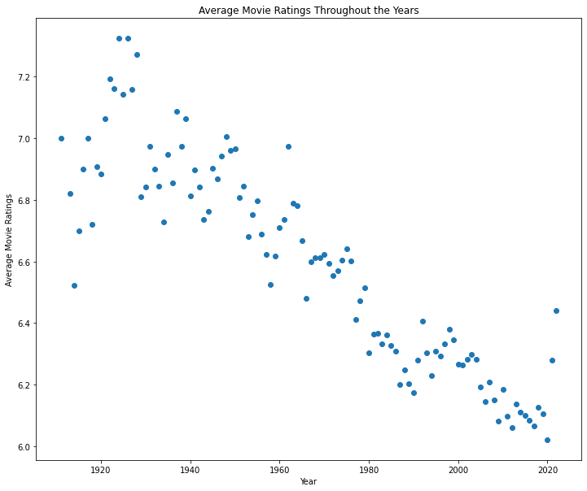

```python
#plots the average yearly runtime of movies that were released in that year
def trendOverYears(df, x, y, xlab, ylab, title):
  matplotlib.rcParams['figure.figsize'] = [12,10]
  fig,ax = plt.subplots()

  #loops through unique years and appends the average of the metric
  avg = []
  for year in info[x].unique():
    yearly = info[info[x] == year]
    avg.append(yearly[y].mean())

  plt.scatter(info[x].unique(), avg)
  plt.xlabel(xlab)
  plt.ylabel(ylab)
  plt.title(title)

info['runtimeMinutes'] = info['runtimeMinutes'].astype(int)
trendOverYears(info, 'releaseYear', 'averageRating', "Year", "Average Movie Ratings", "Average Movie Ratings Throughout the Years")
```

Figure 2: Movie Ratings Over Time

Onto the analysis of average movie rating throughout the years, it is blatantly obvious that general movie satisfaction over the years have drastically dropped from roughly a 7.1 to a 6.1 in recent years. This 1 point drop constitutes roughly a 14.08% decrease in ratings. Although this may seem like the industry is on a downhill spiral, it is important not to jump to conclusions prior to the analysis of various factors and movie features.

**Movie Runtime Over Time**

A factor that I want to take a look at is the trend of movie runtime. Movie runtime is a core part of what makes a movie a movie. It is the distinction that separates a movie from short films and varying lengths of movies will need to use different methods to keep their audiences engaged with the screen.

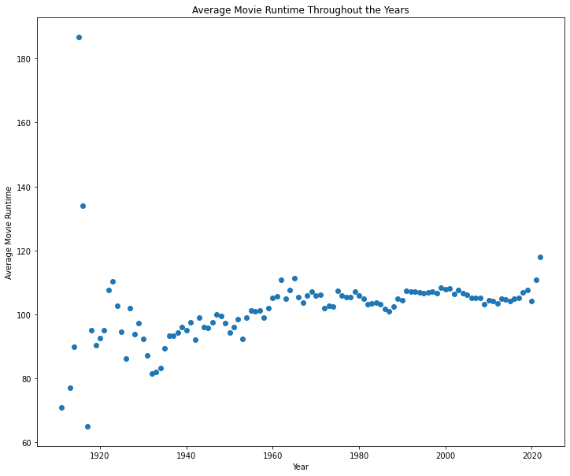

```python
trendOverYears(info, 'releaseYear', 'runtimeMinutes',"Year","Average Movie Runtime", "Average Movie Runtime Throughout the Years")
```

Figure 3A: Movie Runtime over time

As we can see via the graph, there appears to be an increasing linear trend of movie runtime. In the earlier years, we can see a large variance in movie runtime but this might be explainable due to newer technology that the industry was adapting to. In more recent years however, we can observe a somewhat sinusoidal trend along a linear line that spikes particularly hard after 2020.

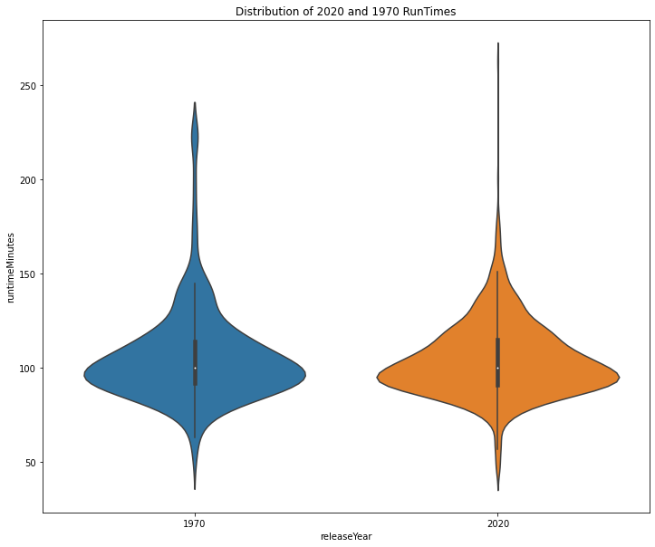

```python
#combines the two dataframes together to represent
movies2020 = info[info['releaseYear'] == 2020]
movies1970 = info[info['releaseYear'] == 1970]
combined = pd.concat([movies2020,movies1970])

sns.violinplot(x = combined.releaseYear, y = combined.runtimeMinutes)
plt.title('Distribution of 2020 and 1970 RunTimes')
```

Figure 3B: Violin Plots of 2020 and 1970 Runtime Distributions Indicating Similar General Runtimes

Using the violin plots allows us to analyze the distribution of runtimes given a specific year. This is a much better visualization as we can compare measurements such as a year's average runtime and spread of runtime.

To map the overall trend throughout the years to see the relationship between time and ratings, we can create a column called 'timePerPoint' where:

$timePerPoint = (runTimeMinutes)/(averageRating)$

Using the column we created, I create a scatter plot by finding the mean time per point of each year. This way, even if there are hundreds of movies in one year that could contain several outliers, the average will suppress it such that we see a metric that is closer to the norm.

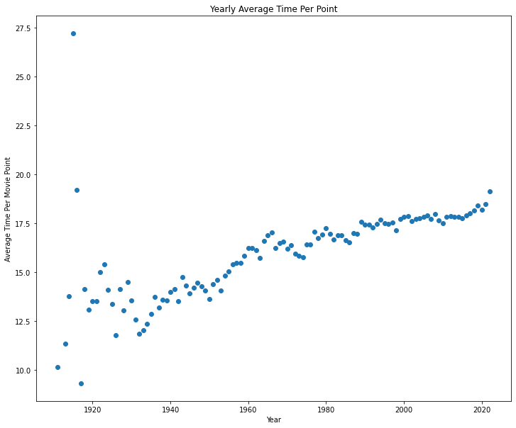

```python
#the amount of the time per point rating
info['timePerPoint'] = info['runtimeMinutes'].astype(float)/info['averageRating']

# plots the graph using the yearly average time/point
matplotlib.rcParams['figure.figsize'] = [12,10]
fig, ax = plt.subplots()

average_year = []
for year in info['releaseYear'].unique():
  yearly = info[info['releaseYear']==year]
  average_year.append(yearly['timePerPoint'].mean())

# plots a scatter plot
plt.scatter([int(x) for x in info['releaseYear'].unique()], average_year)
plt.title('Yearly Average Time Per Point')
plt.xlabel("Year")
plt.ylabel("Average Time Per Movie Point")
```

Figure 3C: Yearly Average Time Per Point sloping upwards linearly

When looking at the scatter plot above, one thing that is visibly noticeable is that the yearly points appear to follow an increasing linear trend. This indicates that, in order for a movie in 2022 to get the same score as a movie in 1920, it will probably have to be longer than its counterpart.

Although the scatter plot above does show the general trend, we can notice that the earlier years of film have a higher level of variance. Additionally, in the earlier graph plotting movie releases per year, we can also note that earlier years of film also had very little to no releases. As such, a more effective way for us to analyze the trend would be to compare the progressions of the industry over the last 50 years.

To go further in depth of understanding this increasing yearly average time per point, we should take a look at two specific periods to analyze the ratio. By analyzing the 1960s and 2010s, we can take a look at the differences in the two periods and their respective skews and clusters.

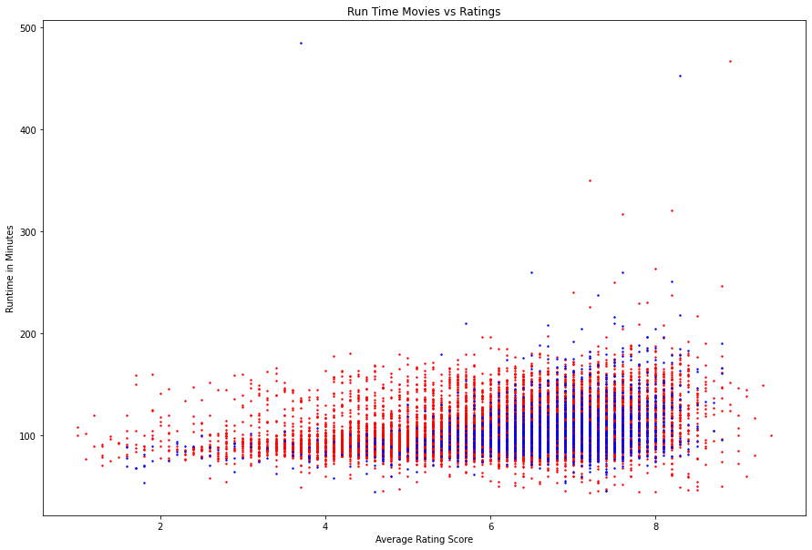

```
Number of Movies in 1960s: 1687
Number of Movies in 2010s: 13127
```

```python
#creating the separate dataframes for the different time periods
movies1960s = info[info['releaseYear']<1970]
movies1960s = movies1960s[1959<movies1960s['releaseYear']]

movies2010s = info[info['releaseYear']<2020]
movies2010s = movies2010s[2009<movies2010s['releaseYear']]

matplotlib.rcParams['figure.figsize'] = [15,10]

plt.scatter(movies2010s['averageRating'], movies2010s['runtimeMinutes'],label = '2010-2019', color = 'red', s= 2)
plt.scatter(movies1960s['averageRating'], movies1960s['runtimeMinutes'], label = '1960-1969', color = 'blue', s = 2)
plt.title('Run Time Movies vs Ratings')
plt.xlabel('Average Rating Score')
plt.ylabel('Runtime in Minutes')
plt.show()


print('Number of Movies in 1960s: '+str(len(movies1960s)))
print('Number of Movies in 2010s: '+str(len(movies2010s)))
```

Figure 4A: Runtime Minutes vs Average Rating Score of Movies in 1960s and 2010s

As we can observe, throughout both periods, there is significant clustering roughly around the 100 minutes mark and 7 point score. For the red marks representing the 2010s, we can see that there are a lot more reaching towards the higher runtimes than the 1960s. Additionally, we can also see that there is a lot more points from the 2010s that receive an average rating below a 5, indicating that many of the movies were considered to be below expectations.

Above, we can also observe that there is a disproportionate number of red points compared to blue points on the data. This is because the red points represent the movies released in the 2010s and the blue points represent the movies released in the 1960s. One method we could to do better visualize this is by taking a random sample from the 2010s that is proportional to the size of the 1960s. The sample could then be used to represent the proportions we would see in the actual population of 2010s.

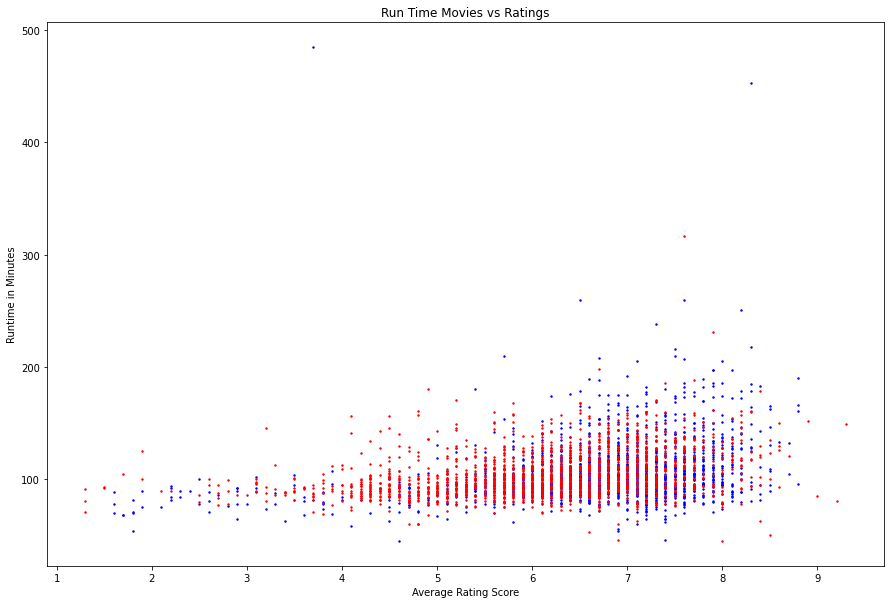

```python
#graphing using the proportionate sample
smovies2010s = movies2010s.sample(n = len(movies1960s))
plt.scatter(movies1960s['averageRating'], movies1960s['runtimeMinutes'], label = '1960-1969', color = 'blue', s = 2)
plt.scatter(smovies2010s['averageRating'], smovies2010s['runtimeMinutes'],label = '2010-2019', color = 'red', s= 2)

plt.title('Run Time Movies vs Ratings')
plt.xlabel('Average Rating Score')
plt.ylabel('Runtime in Minutes')
plt.show()
```

Figure 4B: Runtime in Minutes vs Average Rating of Movies in 1960s and 2010s proportionate to size of 1960s

As you can see, with the proportional sample, we observe that many of the blue points and red points continue to hover around the 100 minutes of movie time. However, after slimming down the sizes by taking a sample, it becomes clearer that the blue cluster for the movies in 1960s tend to cluster at a higher average rating than those from the 2010s.

**Genres over Time**

Another factor that contributes to a movie's success and ratings could be the genre of the film. Below, I go throught he list of genres, and because some films have up to 3 types of genres associated with it, I split them and keep the unique classifications.

```python
# Separates into unique categories so we can
lstOfGenres = []
for genre in info['genres'].unique():
  types = genre.split(',')
  for t in types:
    if((t in lstOfGenres) == False):
      lstOfGenres.append(t)
print(lstOfGenres)
```

```
['Adventure', 'Drama', 'Fantasy', 'Crime', 'Mystery', 'Horror', 'History', 'Action', 'Comedy', 'War', 'Romance', 'Biography', 'Sci-Fi', 'Family', 'Thriller', 'Western', 'Sport', 'Documentary', 'Animation', 'Musical', 'Music', 'Film-Noir', 'News', 'Adult', 'Reality-TV']
```

Given these many types of movies, I now want to represent the data in terms of how well each category does. As such, I could find the average score of each category and use that rating as a metric of comparison.

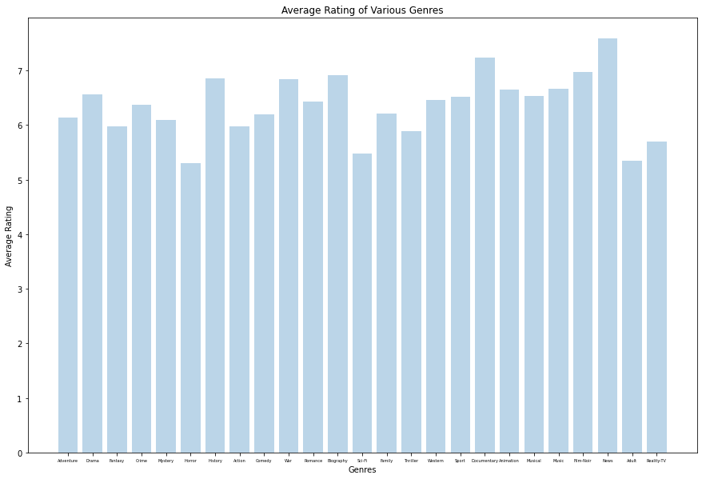

```python
df = pd.DataFrame(columns = ['genre', 'averageRating'])

for genre in lstOfGenres:
  sum = 0
  count = 0

  #loops through all the rows and checks to see if the genre matches
  for i,row in info.iterrows():
    types = row['genres'].split(',')
    if genre in types:
      sum = sum + row['averageRating']
      count = count + 1

  #appends the calculated average back in
  df = df.append({'genre': genre, 'averageRating':sum/count}, ignore_index = True)

#now we want to represent it using bar graphs
plt.bar(df['genre'], df['averageRating'], align='center',alpha = .3)
plt.ylabel('Average Rating')
plt.xlabel('Genres')
plt.title('Average Rating of Various Genres')
plt.xticks(size = 5)
plt.show()
```

Figure 5: Average Rating of Movies Based on Classification of Genre

As we can see, overall, all genres average a rating above 5.0. We can see that some genres, such as movies that are categorized as 'News' or 'Documentary,' have a higher average than many of their counterparts such as those categorized as 'Horror' and 'Adult.'

Obviously, in this portion, we are also potentially double counting, even triple counting, one movie for its various categorizations. We could go deeper into this trend by trying to find the relationship between number of categorizations and their scores.

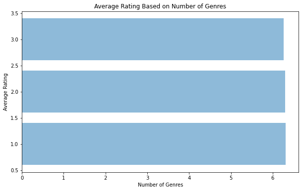

|  | NumberGenres | averageRating |
| --- | --- | --- |
| 0 | 1.0 | 6.306912 |
| 1 | 2.0 | 6.295497 |
| 2 | 3.0 | 6.266426 |

```python
numClass = pd.DataFrame(columns = ['NumberGenres','averageRating'])
matplotlib.rcParams['figure.figsize'] = [10,6]


for num in range(3):
  sum = 0
  count = 0

  #goes through everything and adds up the scores for those that have categorizations as 1 genre, 2 genres, or 3 genres
  for i,row in info.iterrows():
    types = row['genres'].split(',')
    if len(types) == (num+1):
      sum = sum + row['averageRating']
      count = count + 1

  numClass = numClass.append({'NumberGenres': (num + 1), 'averageRating':(sum/count)}, ignore_index = True)

#plot the 3 averages into a bar graph
plt.barh(numClass['NumberGenres'], numClass['averageRating'], align = 'center', alpha = .5)
plt.title('Average Rating Based on Number of Genres')
plt.xlabel('Number of Genres')
plt.ylabel('Average Rating')
plt.xticks()
plt.show()

numClass
```

Figure 6: Average rating based on the number of genres a movie is classified with. Generally consistent.

After delving deeper into the effect genre has on rating, we see that the number of genres that movies are classified has little to no correlation with their average rating. If anything, the average rating of movies that have more genres slightly decreases compared to those that have fewer. This suggests that movies that try to appeal a wider range of audiences may have marginally worse ratings on average than those that focus on one type of movie.

# **Predicting Rating**

Now that we have taken a look at a couple of factors that may affect rating, lets attempt to see whether they can be used to find a predictive relationship with the ratings of movies and runtime.

$H_0$ = Runtime does not have an effect on ratings

$H_A$ = Runtime affects a movie's ratings

RunTime

First we want to represent the relationship in a graph to show runtime vs rating. Because we are trying to predict the effect runtime has for future years, I will be using the 2020 movie dataset from figure 3B as technology from 2020 is more comparable with technology in future years than those from earlier years.

The reason we use a smaller sized sample, specifically one year, to create our regression is to prevent overfitting. Overfitting is when your regression model fits so well into your training data that, when introduced to unseen data, it reports less accurately. (More information at https://www.ibm.com/cloud/learn/overfitting)

When using smaller sample sizes however, it is important to not cut it down too much otherwise you may be underfitting. Underfitting is when you can not capture the relationship between the components accurately because your set is not comprehensive enough. (More information also at https://www.ibm.com/cloud/learn/underfitting)

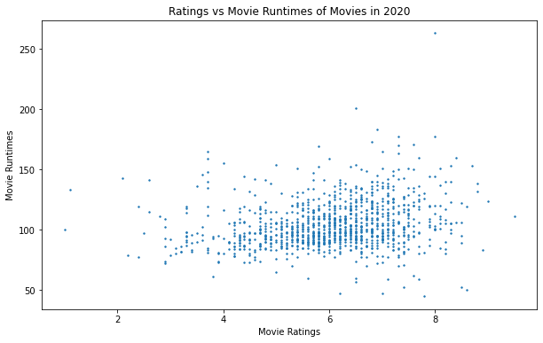

```python
plt.scatter(movies2020['averageRating'], movies2020['runtimeMinutes'], s = 2)
plt.title('Ratings vs Movie Runtimes of Movies in 2020')
plt.ylabel('Movie Runtimes')
plt.xlabel('Movie Ratings')
```

Figure 7A: Movie Ratings vs Runtimes in 2020

Next, we will try to fit a linear regression to see if we can predict the behavior. We can do this using sklearn's statistical modeling for linear regressions. (More information can be found at https://scikit-learn.org/stable/modules/generated/sklearn.linear_model.LinearRegression.html)

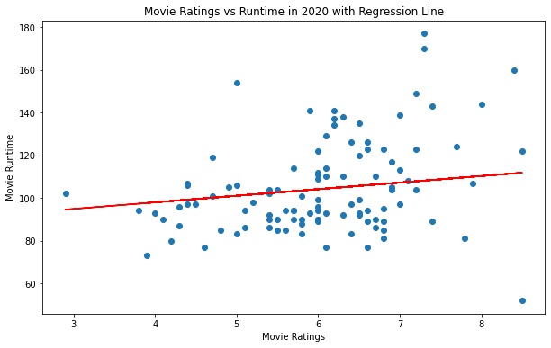

```python
from sklearn.preprocessing import PolynomialFeatures
from sklearn import linear_model
from sklearn.model_selection import train_test_split
from sklearn import preprocessing, svm

X = np.array(movies2020['averageRating']).reshape(-1,1)
Y = np.array(movies2020['runtimeMinutes']).reshape(-1,1)
ind_train, ind_test, dep_train, dep_test = train_test_split(X,Y, test_size = .1)

#creates the linear model using sklearn's linear regression
linearMod = linear_model.LinearRegression()
linearMod.fit(ind_train, dep_train)
predictions = linearMod.predict(ind_test)

plt.scatter(ind_test, dep_test)
plt.plot(ind_test, predictions, color = 'r')
plt.title('Movie Ratings vs Runtime in 2020 with Regression Line')
plt.xlabel('Movie Ratings')
plt.ylabel('Movie Runtime')
plt.show()
```

Figure 7B: Movie Ratings vs Movie Runtimes in 2020 Sample with Linear Regression Line

As we can see, the linear line looks to go right through the middle of the sample data so now we want to find the R^2 coefficient to check the variation of points relative to the line. This gives us an idea of how well the line fits the dataset.

```python
from sklearn.metrics import r2_score

coef = r2_score(dep_test, predictions)
coef
```

```
0.07572175363655387
```

As we can see, we have an incredibly low R^2 score. Low R^2 values indicate that there is not much of a predictive relationship between the independent and dependent variables. (More information on R^2 scores can be found https://statisticsbyjim.com/regression/interpret-r-squared-regression/)

As such, we fail to reject the null hypothesis as the sample makes it such that we are unable to say that there is indeed a relationship between movie runtime and movie ratings.

# Conclusions

Upon the comparison of movie ratings with movie runtimes and genre classification, we can say that there has definitely been a spike in movies released in recent years that correspond to an average decrease in movie ratings. Additionally, through figures 3A and 3B, we can see that, although it may seem like average movie runtime has increased, the proportion of movies' and the distribution of the movies' runtimes have stayed relatively the same over the last 50 years. This tells us that even though film equipment has changed, the industry standard lengths have not. Additionally, observations of the various genres tell us that, although some categories are more highly rated, it really does not have that much of a significant difference and people generally enjoy what they are consuming.

As film continues to progressively improve, I believe that it makes a bit of sense that it is hard to measure a movie's success simply by using its runtime or genre. There are a variety of factors and circumstances that surround a movie that influences its viewership and box office revenue. From famous celebrities to subjective preferences of audiences, there are countless aspects that could result in higher or lower scores. Despite the uncertainties one may have when choosing a movie, one takeaway from this tutorial is that there are plenty of good movies out there so, odds are, many of the movies you look at will entertain you.